# Git_EDA_Data_Cleaning

Elizabeth Esnard

2025-06-17

Load the raw data into a variable

```r
loan_working_copy <- read.csv("C:/Users/lizes/Documents/TMU - Chang School/CIND820/dataset bnpl/loan_working_copy.csv")
```

Check the summary to get a feel of the data.

```r
summary(loan_working_copy)
```

```
##    loan_amnt      loan_term            int_rate     monthly_payment
##  Min.   : 1000   Length:1048575     Min.   : 5.31   Min.   :  14.77
##  1st Qu.: 8000   Class :character   1st Qu.: 9.16   1st Qu.: 251.65
##  Median :13000   Mode  :character   Median :11.99   Median : 380.66
##  Mean   :15385                      Mean   :12.80   Mean   : 453.82
##  3rd Qu.:20000                      3rd Qu.:15.49   3rd Qu.: 609.44
##  Max.   :40000                      Max.   :30.99   Max.   :1670.15
##
##   sub_grade          emp_title          emp_length        home_ownership
##  Length:1048575     Length:1048575     Length:1048575     Length:1048575
##  Class :character   Class :character   Class :character   Class :character
##  Mode  :character   Mode  :character   Mode  :character   Mode  :character
##
##
##
##
##    annual_inc      verification_status loan_purpose        addr_state
##  Min.   :      0   Length:1048575      Length:1048575     Length:1048575
##  1st Qu.:  47000   Class :character    Class :character   Class :character
##  Median :  66000   Mode  :character    Mode  :character   Mode  :character
##  Mean   :  79675
##  3rd Qu.:  95000
##  Max.   :9930475
##
##    total_dti       delinq_2yrs         open_acc      application_type
##  Min.   : -1.00   Min.   : 0.0000   Min.   :  0.00   Length:1048575
##  1st Qu.: 11.93   1st Qu.: 0.0000   1st Qu.:  8.00   Class :character
##  Median : 18.05   Median : 0.0000   Median : 11.00   Mode  :character
##  Mean   : 19.29   Mean   : 0.2974   Mean   : 11.71
##  3rd Qu.: 25.02   3rd Qu.: 0.0000   3rd Qu.: 15.00
##  Max.   :999.00   Max.   :58.0000   Max.   :101.00
##  NA's   :1197
##  cur_acct_delinq     tot_coll_amt      tot_cur_bal         mort_acc
##  Min.   :0.000000   Min.   :      0   Min.   :      0   Min.   : 0.000
##  1st Qu.:0.000000   1st Qu.:      0   1st Qu.:  28834   1st Qu.: 0.000
##  Median :0.000000   Median :      0   Median :  78318   Median : 1.000
##  Mean   :0.003503   Mean   :    243   Mean   : 143579   Mean   : 1.464
##  3rd Qu.:0.000000   3rd Qu.:      0   3rd Qu.: 214930   3rd Qu.: 2.000
##  Max.   :6.000000   Max.   :6214661   Max.   :9971659   Max.   :87.000
##
```

[output cut: 9 more lines]

```
##  Min.   :      0   Length:1048575     Length:1048575      Length:1048575
##  1st Qu.:  20912   Class :character   Class :character    Class :character
##  Median :  38594   Mode  :character   Mode  :character    Mode  :character
##  Mean   :  52307
##  3rd Qu.:  66337
##  Max.   :2622906
##
##  loan_status
##  Length:1048575
##  Class :character
##  Mode  :character
##
##
##
##
```

Confirm the number of rows in the raw data

```r
nrow(loan_working_copy)
```

```
## [1] 1048575
```

Confirm the feature names

```r
colnames(loan_working_copy)
```

```
##  [1] "loan_amnt"            "loan_term"            "int_rate"
##  [4] "monthly_payment"      "sub_grade"            "emp_title"
##  [7] "emp_length"           "home_ownership"       "annual_inc"
## [10] "verification_status"  "loan_purpose"         "addr_state"
## [13] "total_dti"            "delinq_2yrs"          "open_acc"
## [16] "application_type"     "cur_acct_delinq"      "tot_coll_amt"
## [19] "tot_cur_bal"          "mort_acc"             "num_accts_120_pd"
## [22] "pub_rec_bankruptcies" "tax_liens"            "credit_limit"
## [25] "total_bal_ex_mort"    "hardship_flag"        "disbursement_method"
## [28] "debt_settlement_flag" "loan_status"
```

Filter the raw data into a subset that simulates BNPL purchase amounts.

```r
BNPL_clients <- loan_working_copy[(loan_working_copy$loan_amnt <= 3500), ]
nrow(BNPL_clients)
```

```
## [1] 59092
```

**Identifying the Target Variable.**

First, confirm all possible categories in the target variable feature.

```r
unique(BNPL_clients$loan_status)
```

```
## [1] "Current"            "Fully Paid"         "In Grace Period"
## [4] "Late (31-120 days)" "Late (16-30 days)"  "Charged Off"
## [7] "Default"
```

We’ll change all the categories into the two desired targets; solvent and default.

```r
library(dplyr)
BNPL_clients$loan_status <- recode(BNPL_clients$loan_status, "Current" = "solvent", "Fully Paid" = "solvent", "In Grace Period" = "solvent", "Late (16-30 days)" = "default")

BNPL_clients$loan_status <- recode(BNPL_clients$loan_status, "Late (31-120 days)" = "default", "Charged Off" = "default", "Default" = "default")
```

Confirm the distribution of the target variable. Both in a standard way (barplot function) and with a package to clean up the plot.

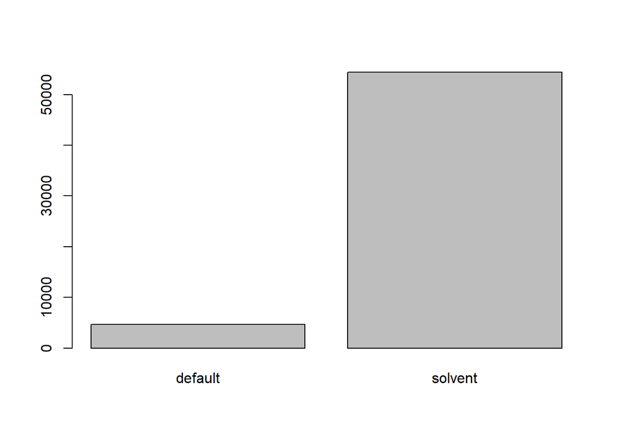

```r
barplot((table(BNPL_clients$loan_status)))
```

To add some customization on axis labels, we’ll plot again with ggplot2

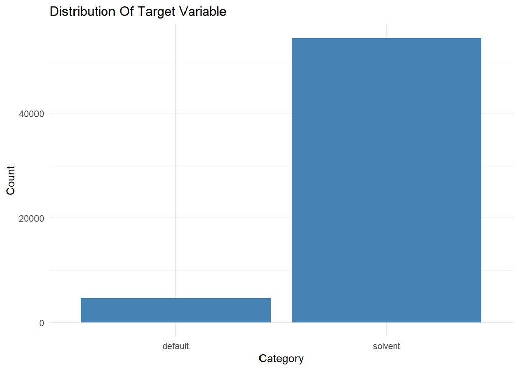

```r
library(ggplot2)
ggplot(BNPL_clients, aes(loan_status)) +
  geom_bar(fill = "steelblue") +
  labs(title = "Distribution Of Target Variable",
       x = "Category",
       y = "Count") +
  theme_minimal()
```

There is a clear imbalance of the target variable, so there will be SMOTE oversampling to assist in the modeling.

Next, let’s confirm the class type of all the features.

```r
sapply(BNPL_clients, class)
```

```
##            loan_amnt            loan_term             int_rate
##            "integer"          "character"            "numeric"
##      monthly_payment            sub_grade            emp_title
##            "numeric"          "character"          "character"
##           emp_length       home_ownership           annual_inc
##          "character"          "character"            "numeric"
##  verification_status         loan_purpose           addr_state
##          "character"          "character"          "character"
##            total_dti          delinq_2yrs             open_acc
##            "numeric"            "integer"            "integer"
##     application_type      cur_acct_delinq         tot_coll_amt
##          "character"            "integer"            "integer"
##          tot_cur_bal             mort_acc     num_accts_120_pd
##            "integer"            "integer"            "integer"
## pub_rec_bankruptcies            tax_liens         credit_limit
##            "integer"            "integer"            "integer"
##    total_bal_ex_mort        hardship_flag  disbursement_method
##            "integer"          "character"          "character"
## debt_settlement_flag          loan_status
##          "character"          "character"
```

```r
column_types <- data.frame(
  column = colnames(BNPL_clients),
  class = sapply(BNPL_clients, class)
)
```

Although there are a number of integer and/or numeric values, not all are truly numeric. Exploring the dataset in a spreadsheet, it’s clear these values act as categories (e.g. 0 = no, 1 = yes) so through human logic I identified the true numeric features that summary statistics will reveal insightful information.

```r
BNPL_numeric <- BNPL_clients[c('loan_amnt', 'int_rate', 'monthly_payment', 'annual_inc', 'total_dti', 'tot_coll_amt', 'tot_cur_bal', 'credit_limit')]

summary(BNPL_numeric)
```

```
##    loan_amnt       int_rate     monthly_payment    annual_inc
##  Min.   :1000   Min.   : 5.31   Min.   : 29.76   Min.   :      0
##  1st Qu.:2000   1st Qu.: 9.76   1st Qu.: 63.19   1st Qu.:  32756
##  Median :2500   Median :12.69   Median : 85.44   Median :  48000
##  Mean   :2417   Mean   :13.20   Mean   : 81.55   Mean   :  54439
##  3rd Qu.:3000   3rd Qu.:15.99   3rd Qu.:101.80   3rd Qu.:  67000
##  Max.   :3500   Max.   :30.99   Max.   :149.53   Max.   :7000000
##
##    total_dti       tot_coll_amt       tot_cur_bal       credit_limit
##  Min.   :  0.00   Min.   :     0.0   Min.   :      0   Min.   :      0
##  1st Qu.: 10.69   1st Qu.:     0.0   1st Qu.:  15497   1st Qu.:  30450
##  Median : 17.17   Median :     0.0   Median :  40150   Median :  62967
##  Mean   : 18.15   Mean   :   257.2   Mean   :  90535   Mean   : 115382
##  3rd Qu.: 24.40   3rd Qu.:     0.0   3rd Qu.: 135296   3rd Qu.: 167608
##  Max.   :999.00   Max.   :208593.0   Max.   :1389307   Max.   :9999999
##  NA's   :39
```

There is a clear outlier with the max income being 7,000,000 despite the max loan amount being set to $3500. Let’s check the distribution of the annual income feature

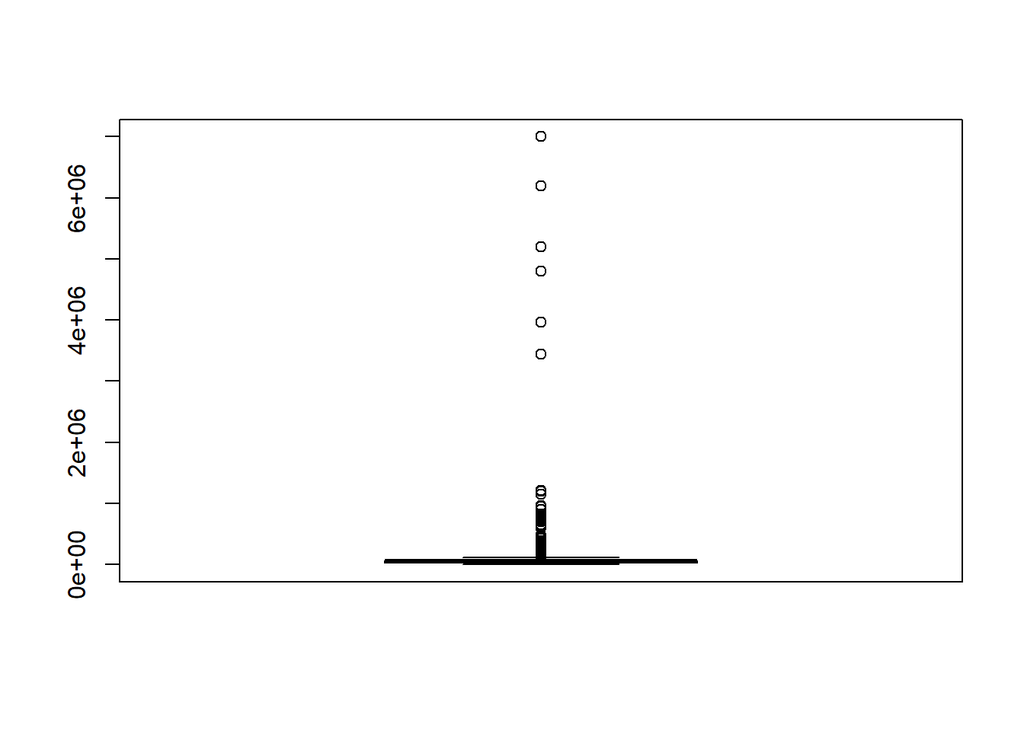

```r
boxplot(BNPL_clients$annual_inc)
```

The distribution is so skewed, we hardly see the box plot. Let’s move to ggplot2 for more control.

```r
#install.packages("scales")
library(scales)
```

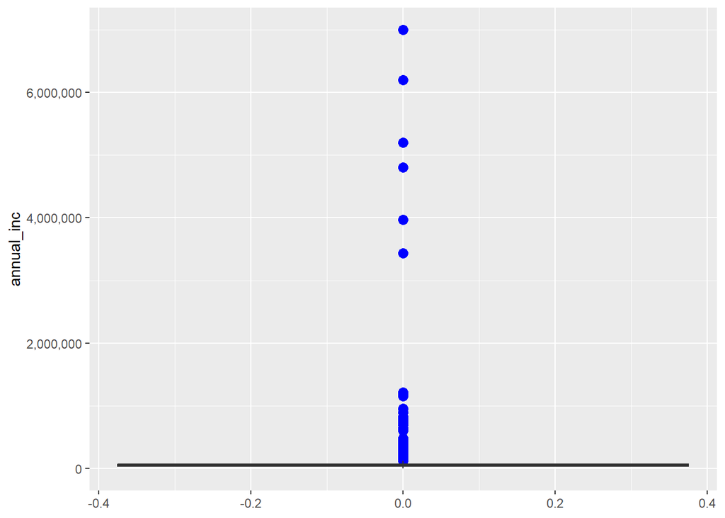

```r
library(ggplot2)

ggplot(BNPL_clients, aes(y=annual_inc)) +
  geom_boxplot(outlier.colour = "blue", outlier.shape = 16,
               outlier.size = 3, notch = FALSE) +
  scale_y_continuous(
    limits = c(0, 7000000),
    labels = scales::comma
  )
```

As we can clearly see, the outliers for a reasonable annual income are off the charts. As a test, let’s calculate the quartiles and limit to the 3rd quartile to inspect the distribution

```r
quantile(BNPL_clients$annual_inc)
```

```
##      0%     25%     50%     75%    100%
##       0   32756   48000   67000 7000000
```

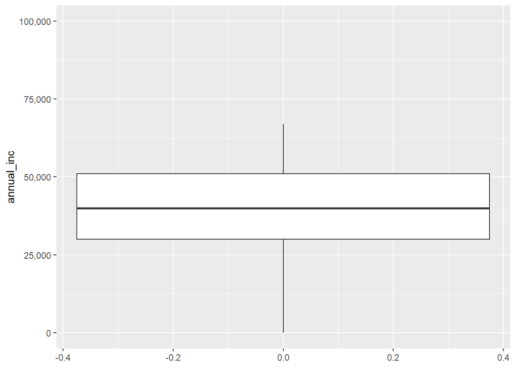

```r
library(ggplot2)

BNPL_anninc_3rdQ <- BNPL_clients[(BNPL_clients$annual_inc <= 67000),]

ggplot(BNPL_anninc_3rdQ, aes(y=annual_inc)) +
  geom_boxplot(outlier.colour = "blue", outlier.shape = 16,
               outlier.size = 3, notch = FALSE) +
  scale_y_continuous(
    limits = c(0, 100000),
    labels = scales::comma
  )
```

```r
nrow(BNPL_anninc_3rdQ)
```

```
## [1] 44370
```

Reducing the annual income to the 3rd quartile has a better distribution than previously seen, but reduces the number of observations to under 45,000. So balance out annual income, we’ll set the max of annual income to $100,000. This level of income is likely to still engage in BNPL services.

```r
BNPL_clients <- BNPL_clients[(BNPL_clients$annual_inc <= 100000),]
```

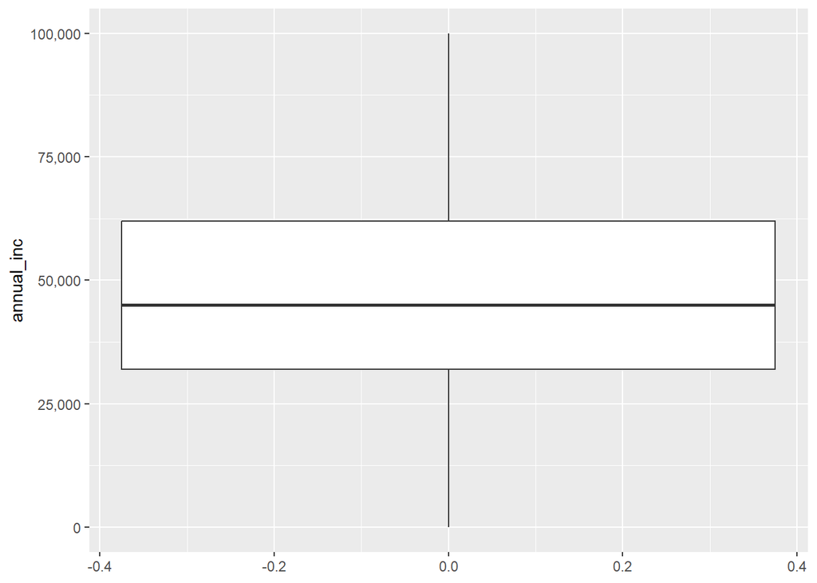

```r
library(ggplot2)

ggplot(BNPL_clients, aes(y=annual_inc)) +
  geom_boxplot(outlier.colour = "blue", outlier.shape = 16,
               outlier.size = 3, notch = FALSE) +
  scale_y_continuous(
    limits = c(0, 100000),
    labels = scales::comma
  )
```

**Identifying Missing Values**

Now to identify any missing or null values that could affect models.

```r
colSums(is.na.data.frame(BNPL_clients))
```

```
##            loan_amnt            loan_term             int_rate
##                    0                    0                    0
##      monthly_payment            sub_grade            emp_title
##                    0                    0                    1
##           emp_length       home_ownership           annual_inc
##                    0                    0                    0
##  verification_status         loan_purpose           addr_state
##                    0                    0                    0
##            total_dti          delinq_2yrs             open_acc
##                   39                    0                    0
##     application_type      cur_acct_delinq         tot_coll_amt
##                    0                    0                    0
##          tot_cur_bal             mort_acc     num_accts_120_pd
##                    0                    0                    0
## pub_rec_bankruptcies            tax_liens         credit_limit
##                    0                    0                    0
##    total_bal_ex_mort        hardship_flag  disbursement_method
##                    0                    0                    0
## debt_settlement_flag          loan_status
##                    0                    0
```

```r
head(unique(BNPL_clients$emp_title), 20)
```

```
##  [1] "Chef"                            "Account Manager"
##  [3] "respritory therapist"            "gas attendant"
##  [5] "Program Manager"                 "Budget & Procurement Specialist"
##  [7] ""                                "BANKER"
##  [9] "Laborer"                         "IT Assistant"
## [11] "Banker "                         "Project manager"
## [13] "Tech Driver"                     "Product Line Specilalist "
## [15] "Room Attendant"                  "Cna"
## [17] "Driver"                          "Service Consultant "
## [19] "Haz Mat S/R"                     "Lpn"
```

As seen through the unique function, as well as visual confirmation when browsing the data as a spreadsheet, the emp_title feature cannot easily be grouped or categorized. emp_title will not greatly contribute to model prediction, and will be removed from the working dataset.

```r
count(BNPL_clients[c((BNPL_clients$emp_title == ""),(BNPL_clients$emp_title == " ")), ])
```

```
##      n
## 1 7665
```

```r
nrow(BNPL_clients[BNPL_clients$loan_status == 'default',])
```

```
## [1] 4505
```

```r
nrow(BNPL_clients[BNPL_clients$loan_status == 'solvent',])
```

```
## [1] 50663
```

```r
nrow(BNPL_clients[is.na(BNPL_clients$total_dti) & BNPL_clients$loan_status == 'solvent', ])
```

```
## [1] 36
```

```r
#remove 36 observations with total_dti missing
BNPL_clients <- BNPL_clients[!(is.na(BNPL_clients$total_dti) & BNPL_clients$loan_status == 'solvent'), ]

#remove emp_title column
BNPL_clients <- subset(BNPL_clients, select = -c(emp_title))

#replace NA values in emp_length
BNPL_clients$emp_length[BNPL_clients$emp_length == ' '] <- "5 years"
BNPL_clients$emp_length[(BNPL_clients$emp_length == 'n/a')] <- "5 years"
count(BNPL_clients[c((BNPL_clients$emp_title == ""),(BNPL_clients$emp_title == " ")), ])
```

```
##   n
## 1 0
```

Quickly we will check the distribution of emp_length with the filled in NA values.

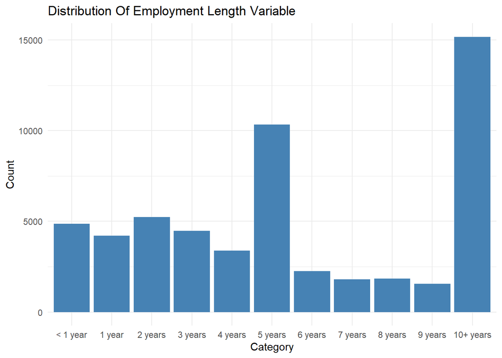

```r
#barplot of emp_length distribution

#order the categories as factors so '10+ years" is at the end of the chart
BNPL_clients$emp_length <- factor(
  BNPL_clients$emp_length,
  levels = c("< 1 year", "1 year", "2 years", "3 years", "4 years", "5 years", "6 years", "7 years", "8 years", "9 years", "10+ years"),
  ordered = TRUE
)

ggplot(BNPL_clients, aes(emp_length)) +
  geom_bar(fill = "steelblue") +
  labs(title = "Distribution Of Employment Length Variable",
       x = "Category",
       y = "Count") +
  theme_minimal()
```

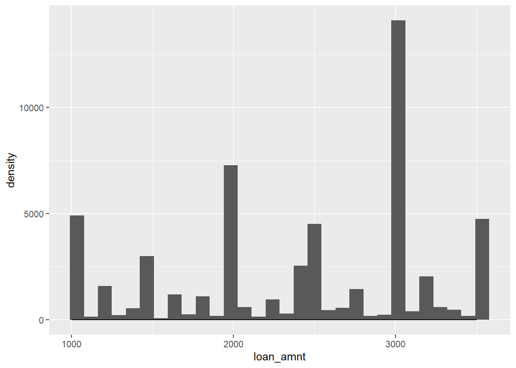

```r
#barplot of loan_amount
ggplot(BNPL_clients, aes(x = loan_amnt)) + geom_histogram() +
  geom_density()
```

The data cleaning is now complete and can be exported.

```r
#export the file to working directory.

#install.packages("openxlsx")
library(openxlsx)
write.xlsx(BNPL_clients, "clean_BNPL_clients.xlsx", rowNames = FALSE)
```

```r
write.csv(BNPL_clients, "clean_BNPL_clients.csv", row.names = FALSE)
```